# misión-exploración

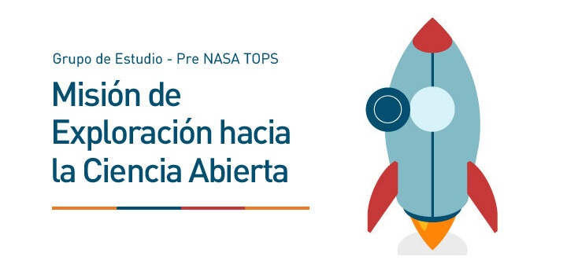

## Who signed up?

A total of 94 participants from 18 different countries signed up for the sessions.

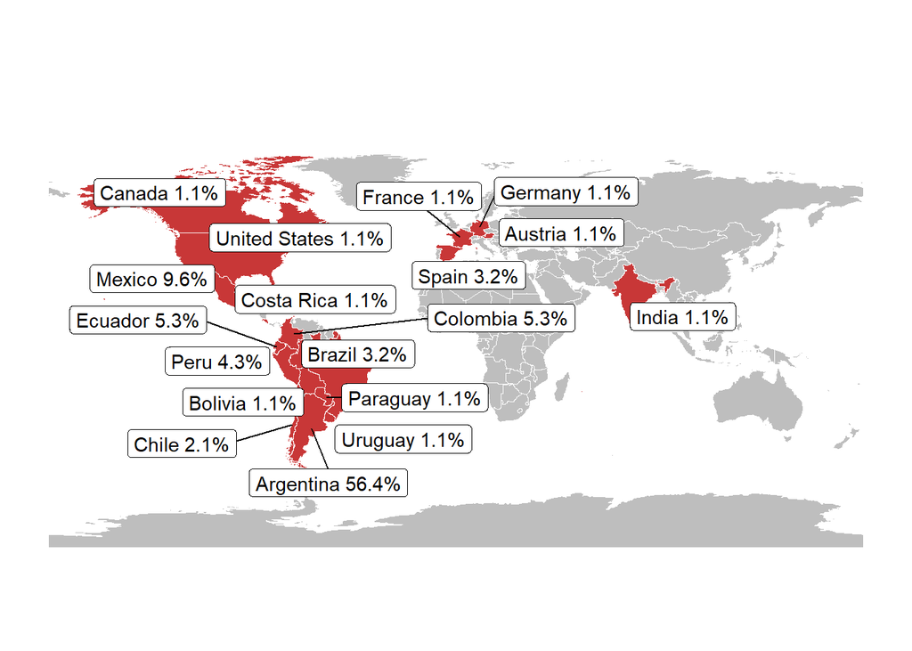

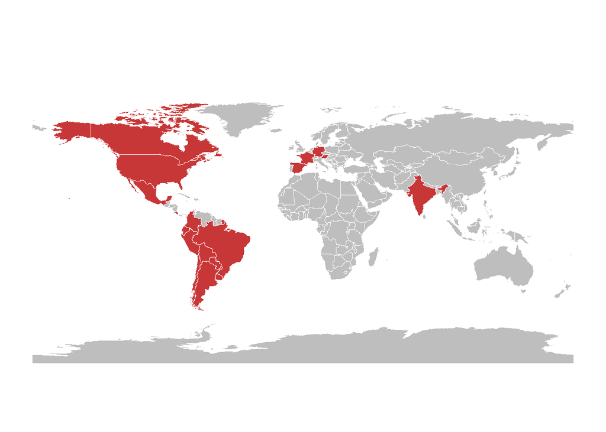

## Community

Out of the 94 who showed interest in the event, 25 reported participating as representatives of a community.

| Community | N | % |
| --- | --- | --- |
| @openlabec, openlab.ec | 1 | 1.1 |
| Abrmios.info | 1 | 1.1 |
| Epidemiología Perú, https://www.facebook.com/profile.php?id=100063770093129 | 1 | 1.1 |
| Fundación Charles Darwin https://www.darwinfoundation.org/es/ | 1 | 1.1 |
| ILDA | 1 | 1.1 |
| MetaDocencia | 8 | 8.5 |
| Nibö, niboe.info | 1 | 1.1 |
| Proyecto CoAct | 1 | 1.1 |
| Python Norte SciPy LA Escuela Bayesiana UNSa | 1 | 1.1 |
| R-Ladies Guayaquil - @RLadiesGye | 1 | 1.1 |
| Revista Propulsión https://ojs.revpropulsion.cl/index.php/revpropulsion/index | 1 | 1.1 |
| SciELO México - https://www.facebook.com/ScieloMexicoOficial/ | 1 | 1.1 |
| Secretaría de Investigación - Facultad de Ciencias Sociales - UNCórdoba https://sociales.unc.edu.ar/ | 1 | 1.1 |
| Sistema de Bibliotecas, Universidad de Guadalajara (https://bibliotecas.udg.mx/) | 1 | 1.1 |
| UNLP | 1 | 1.1 |
| Universidad de costa rica | 1 | 1.1 |
| eScire - www.escire.lat | 1 | 1.1 |
| www.bibliotecarural.com | 1 | 1.1 |

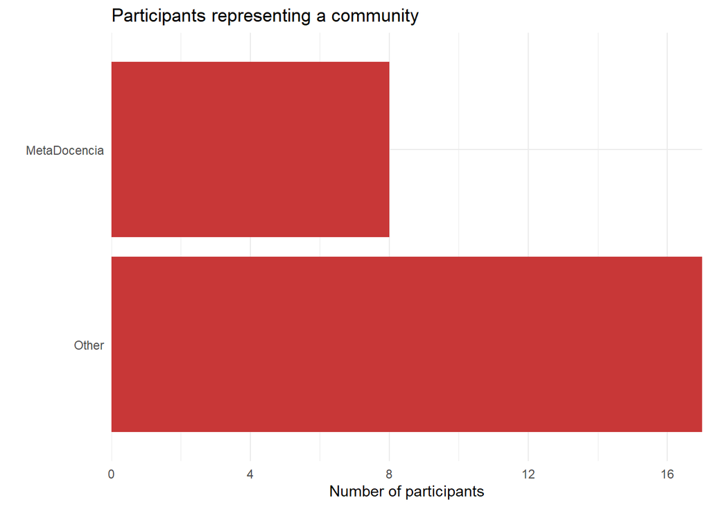

## Accessibility requirements

All accessibility requests were related to language accessibility. Out of the 94 persons who recorded their interest for the event, a total of 14 (14.9%) participants requested interpretation, subtitles, and/or translation to Spanish in the case of English materials or talks.

| Accessibility | N | % |
| --- | --- | --- |
| Interpretation, translation, or subtitles in Spanish | 14 | 14.9 |
| No requirements | 79 | 84.0 |
| Share recording | 1 | 1.1 |

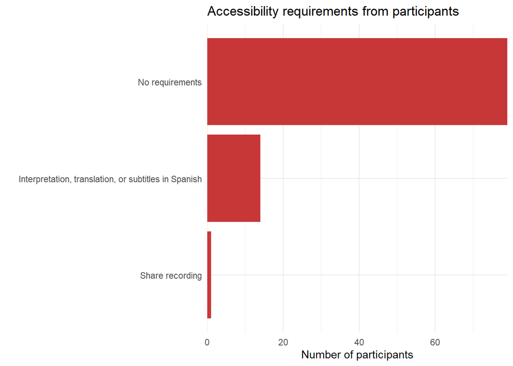

## How did participants learned about the activity?

The 50.5% (n = 54) of the participants learned about the activity through Email and An acquaintance.

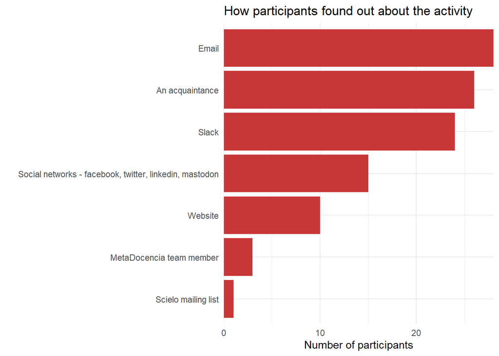

## Why are participants interested in this activity?

- Expanding their knowledge about OS
- Acquiring tools for their practice
- Working in or reseaching OS

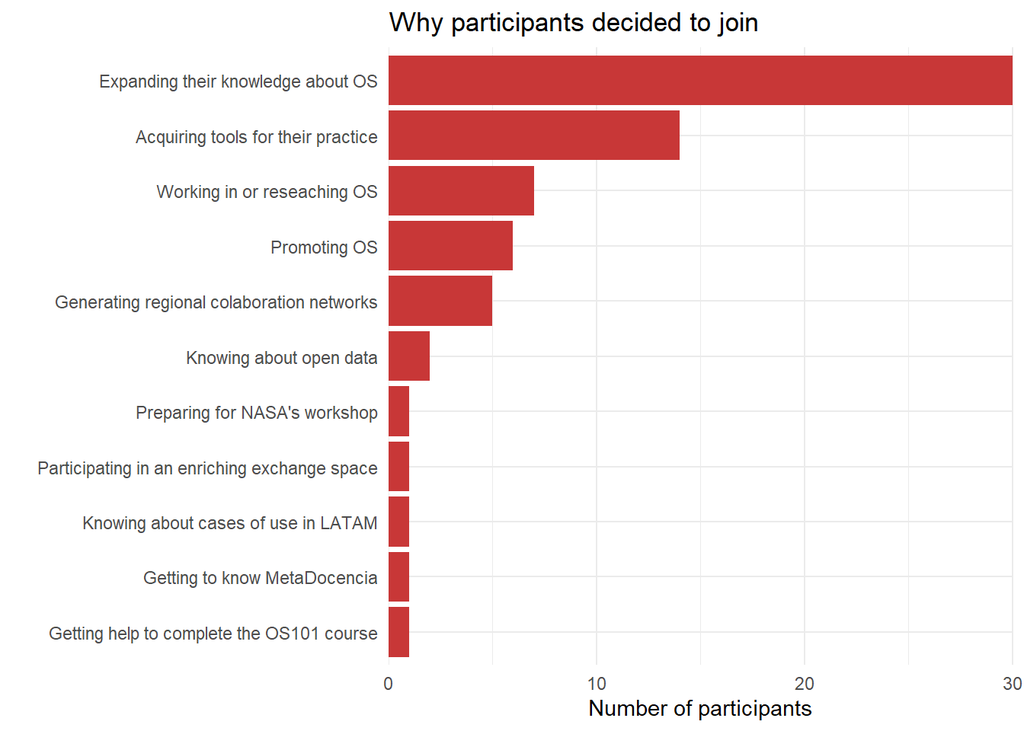

## What was participation in zoom like?

Out of the 94 participants who signed up, 83 (88.3%) attended the meetings.

| Event | N | % |
| --- | --- | --- |
| 06-03-2024 | 21 | 22.3 |
| 07-02-2024 | 25 | 26.6 |
| 13-03-2024 | 28 | 29.8 |
| 14-02-2024 | 16 | 17.0 |
| 20-03-2024 | 33 | 35.1 |
| 21-02-2024 | 18 | 19.1 |
| 24-01-2024 | 29 | 30.9 |
| 27-03-2024 | 19 | 20.2 |
| 31-01-2024 | 26 | 27.7 |

The mean assistance per event was of 23.9 participants (SD = 5.7).

| Event | Attendees | Stayed the hour | % |
| --- | --- | --- | --- |
| 06-03-2024 | 21 | 18 | 85.7 |
| 07-02-2024 | 25 | 20 | 80.0 |
| 13-03-2024 | 28 | 22 | 78.6 |
| 14-02-2024 | 16 | 15 | 93.8 |
| 20-03-2024 | 33 | 27 | 81.8 |
| 21-02-2024 | 18 | 15 | 83.3 |
| 24-01-2024 | 29 | 24 | 82.8 |
| 27-03-2024 | 19 | 16 | 84.2 |
| 31-01-2024 | 26 | 20 | 76.9 |

A mean of 83% of attendees stayed until the end of the sessions. The mean assistance time was of 67.1 minutes, with a standard deviation of 24.3.

## We got certified!

Out of the 83 participants that attended the zoom meetings, 21 (25.3%) got their NASA TOPS certification.

## Insights from the participants’ feedback

### Net Promoter Score

We classified participants into promoters (scores 9-10), who are highly satisfied and very likely to recommend the activity to others; passives or neutrals (scores 7-8), who are somewhat satisfied but may not be as enthusiastic in their recommendations; and detractors (scores 0-6), who are dissatisfied and may actively discourage others from participating.

To calculate the NPS, we subtract the percentage of detractors from the percentage of promoters. The score can range from -100 (if all respondents are detractors) to +100 (if all respondents are promoters).

By doing so, we obtained an NPS of 79.2%. An NPS above 20% is considered favorable, and above 50% excellent.

### Things to keep

After each meeting, we asked participants to share one thing they liked about the encounter and that they would like to keep. We grouped responses into the following categories:

- **Multiple perspectives and discussion** includes comments regarding interdisciplinarity, the space to share experiences and perspectives, and how enriching different points of view can be.
- **Format and presentation** includes comments regarding the participative format, how the sessions were led, and the materials that were shared, such as slides and shared documents.
- **Community** includes comments that explicitly mentioned the word “community,” but also those highlighting the importance of a shared experience.
- **Content** includes comments referring specifically to the information that was shared during the meeting.
- **Latin American context** and **Spanish language** includes comments that explicitly mentioned these subjects.

A participant’s response may fall under more than one category when they include various subjects.

Out of the 72 responses we got, 61.1% (44 participants) highlighted aspects related to Multiple perspectives and discussion; 25% (18 participants) focus on Format and presentation; and 12.5% (9 participants) emphasized the Latin American context aspect of the activity. These were the most frequent categories.

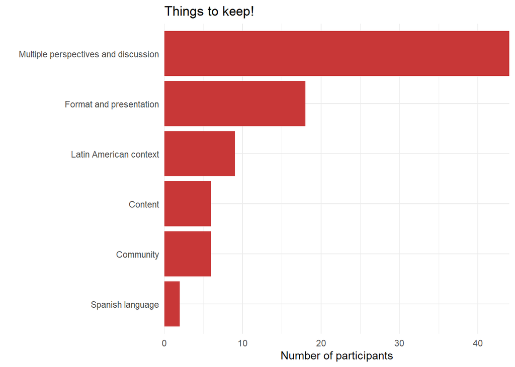

As a whole, we conclude that the attendees appreciated the diverse perspectives and engaging discussions, which was possible due to the dynamic format we used. Spaces of exchange such as this, foster a sense of community, specially when we contextualize the content to the participants’ region and language, all contributing to a rich and valuable experience.

### Things to improve

After each meeting, we asked participants to share suggestions they have to improve the encounters. We grouped responses into the following categories:

- **Longer meetings** includes suggestions to extend the duration of the meetings.
- **Organize interactions** includes comments regarding how the attendees participated and how this can be distracting in some cases.
- **Translate the content that is in English** includes comments regarding the content’s language as a barrier.
- **Extend the discussion** refers to the suggestion of making other channels of communication available to discuss these subjects asynchronously, through the use of the share document, and also to the suggestion of participating in breakout rooms.
- **Limit hipertextuality** refers to the amount of links and externar references in the material.
- **Present a map of the subject**, **Relate reading materials to Latin America**, **Create a repository that centralizes first steps**, **Overlap of materials**, **Timing** and **Expand on the applicability across fields** where mentioned explicitely.

A participant’s response may fall under more than one category when they include various subjects.

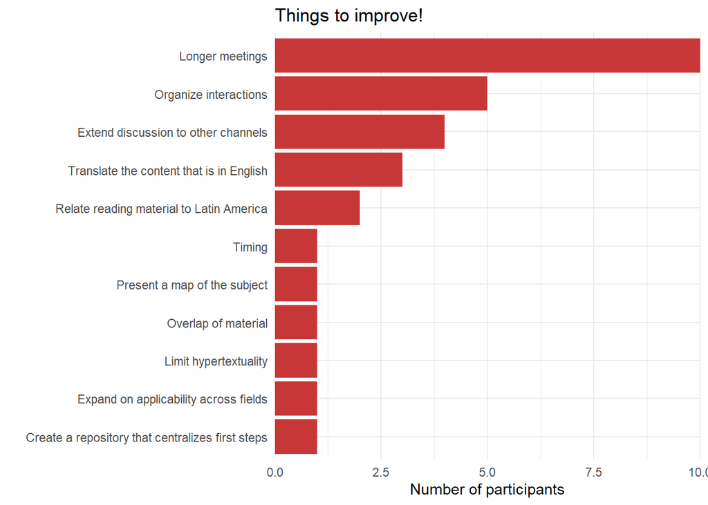

Taken together, we conclude that the suggestions for improvement are mostly focused on enhancing the interactive elements through extending meeting duration, broadening discussions to additional platforms, providing translations for English content, delving into the relevance across various disciplines, and integrating reading materials relevant to the Latin American context.

## Joined slack!

Currently, the #nasa-tops channel has 58 members, 61.7% of the total of participants who signed up for Misión de Exploración (94), out of which 31 (33%) actively participate in the channel.